# Land use and microbe prevalence jointly determine host-microbe network structure

Analysis and results

Matan Markfeld

Last edit: 2024-07-22

```r
source("modularity_analysis_functions.R", local = knitr::knit_global())
```

```r
# reading the microbiome data
# working only with Rattus from the three villages

# villages: Andatsakala, Mandena, Sarahandrano
vil <- "Mandena"
data_asv <- read_csv("../data/data_processed/microbiome/data_asv_rra0.001_p0.01_th5000.csv") %>% filter(village == vil)
```

# 1 Exploration

```r
# small mammals data
small_mammals <- read_csv("../data/data_raw/data_small_mammals/Terrestrial_Mammals.csv") %>%
  mutate(host_ID = as.numeric(gsub(".*?([0-9]+).*", "\\1", animal_id))) %>%
  mutate(age_repro = as_factor(age_repro)) %>%
  dplyr::rename(grid = habitat_type) %>%
  filter(host_ID %in% data_asv$host_ID)

cat("## Abundance", '\n','\n')
```

## 1.1 Abundance

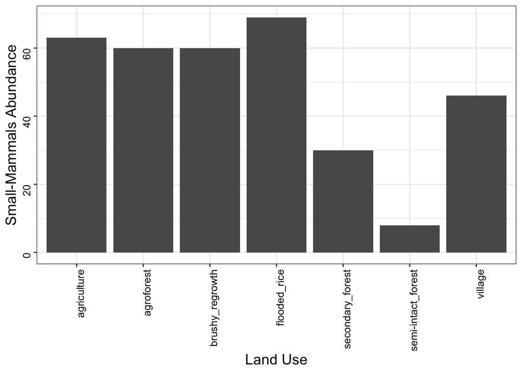

```r
g <- small_mammals %>%
  count(grid) %>%
  ggplot(aes(x=grid, y=n)) +
  geom_bar(position="dodge", stat="identity") +
  theme_bw() +
  theme(axis.text = element_text(size = 10, color = 'black', angle = 90, vjust = 0.5, hjust=1), title = element_text(size = 14)) +
  labs(x="Land Use", y="Small-Mammals Abundance")
print(g)
```

```r
cat("## Sex ratio", '\n','\n')
```

## 1.2 Sex ratio

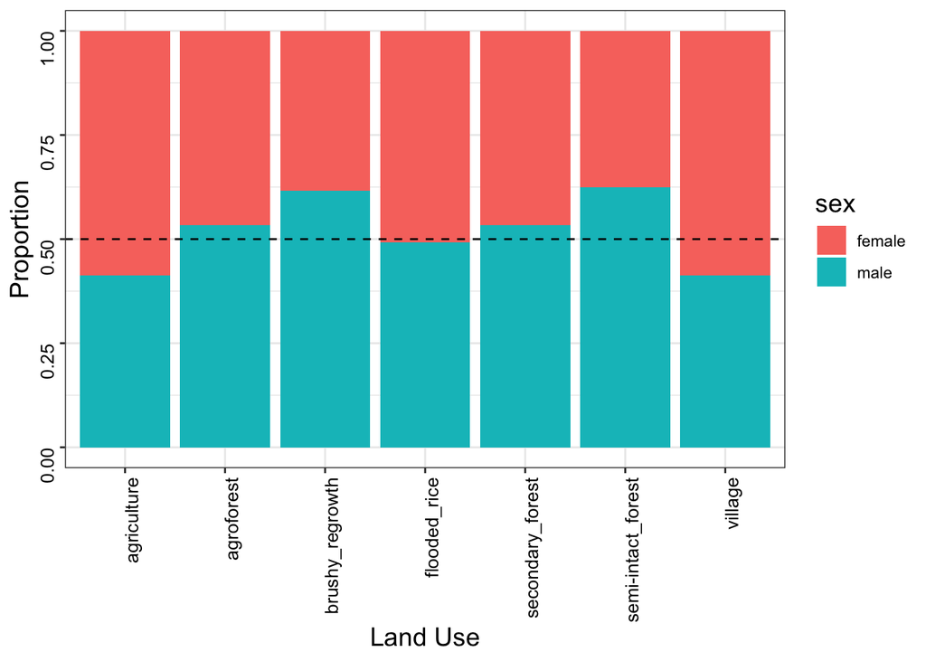

```r
g <- small_mammals %>%
  count(grid, sex) %>%
  ggplot(aes(fill=sex, x=grid, y=n)) +
  geom_bar(position="fill", stat="identity") +
  geom_hline(yintercept = 0.5, linetype = "dashed") +
  theme_bw() +
  theme(axis.text = element_text(size = 10, color = 'black', angle = 90, vjust = 0.5, hjust=1), title = element_text(size = 14)) +
  labs(x="Land Use", y="Proportion")
print(g)
```

```r
cat("## Age ratio", '\n','\n')
```

## 1.3 Age ratio

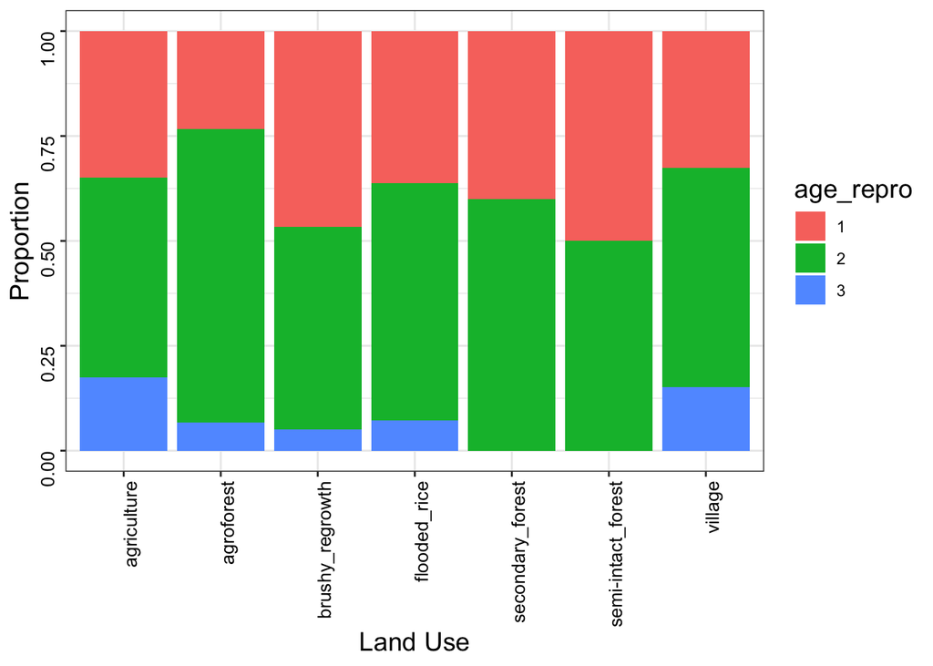

```r
g <- small_mammals %>%
  count(grid, age_repro) %>%
  ggplot(aes(fill=age_repro, x=grid, y=n)) +
  geom_bar(position="fill", stat="identity") +
  theme_bw() +
  theme(axis.text = element_text(size = 10, color = 'black', angle = 90, vjust = 0.5, hjust=1), title = element_text(size = 14)) +
  labs(x="Land Use", y="Proportion")
print(g)
```

```r
# relative abundance of the 10 most abundant Family of each group

# microbes taxonomy
tax <- read_delim("../data/data_raw/data_microbiome/ASVs_taxonomy_new.tsv") %>%
  dplyr::rename(asv_ID = ASV)

data_asv_tax <- data_asv %>%
  left_join(tax, by="asv_ID")

cat("## Relative abundance Family", '\n','\n')
```

## 1.4 Relative abundance Family

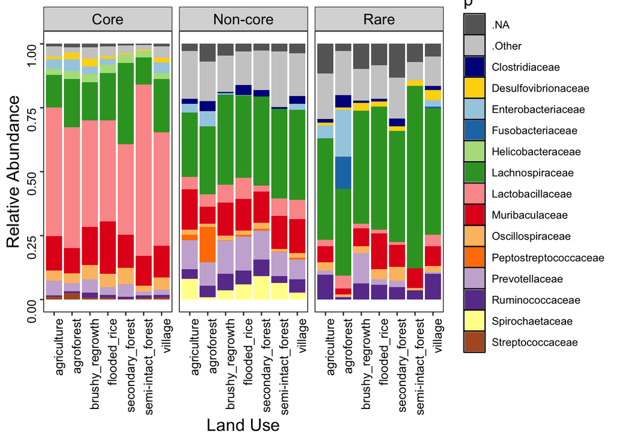

```r
total_reads_groups <- data_asv_tax %>% distinct(host_ID, asv_core, total_reads) %>% group_by(asv_core) %>% summarise(n_total = sum(total_reads))
most_abu_family <- data_asv_tax %>%
  mutate(reads_a = reads*total_reads) %>%
  group_by(asv_core, Family) %>%
  summarise(n= sum(reads_a)) %>%
  left_join(total_reads_groups, by="asv_core") %>%
  mutate(n_p = n/n_total)

  most_abu_family_8 <- most_abu_family %>%
    filter(!is.na(Family)) %>%
    ungroup() %>%
    slice_max(by = asv_core, order_by = n_p, n = 10) %>%
    mutate(p = "top") %>%
    select(asv_core, Family, p)

  most_abu_family_p <- data_asv_tax %>%
  mutate(reads_a = reads*total_reads) %>%
  group_by(asv_core, Family, grid) %>%
  summarise(n= sum(reads_a)) %>%
  left_join(total_reads_groups, by="asv_core") %>%
  mutate(n_p = n/n_total) %>%
    left_join(most_abu_family_8, by=c("asv_core","Family")) %>%
    mutate(p = case_when(p=="top" ~ Family,
                         is.na(Family) ~ ".NA",
                         is.na(p) ~ ".Other"))
library("RColorBrewer")
colors <- c("grey40","grey80","darkblue","#ffd60a",brewer.pal(n = 12, name = "Paired"))
  g <- most_abu_family_p %>%
    group_by(asv_core,grid,  p) %>%
    summarise(n_p = sum(n_p)) %>%
ggplot(aes(fill=p, x=grid, y=n_p)) +
  geom_bar(position="fill", stat="identity") +
  facet_wrap(~asv_core) +
  theme_bw() +
  theme(axis.text = element_text(size = 10, color = 'black', angle = 90, vjust = 0.5, hjust=1), title = element_text(size = 14),
        strip.text = element_text(size=12, color = 'black'),
        panel.grid = element_blank(), panel.background = element_rect(colour = "black")) +
  scale_fill_manual(values=colors) +
  labs(x="Land Use", y="Relative Abundance")
print(g)
```

```r
cat('\n','\n')
```

# 2 PERMANOVA

## 2.1 Bray-Curtis

```r
set.seed(123)
data_asv_mat <- data_asv %>%
  #filter(asv_core == "Rare") %>%
  select(host_ID, asv_ID, reads) %>%
  spread(asv_ID, reads, fill = 0) %>%
  column_to_rownames("host_ID") %>%
  as.matrix()

hosts <- small_mammals %>%
  filter(host_ID %in% rownames(data_asv_mat)) %>%
  select(host_ID,grid,season,month,mass, sex,age_repro,age_dental,elevation.obs) %>%
  mutate(grid=as.factor(grid), season=as.factor(season),month=as.factor(month), sex=as.factor(sex), age_dental=as.factor(age_dental))

distance_matrix <- vegdist(data_asv_mat, method = "bray")

# Perform PERMANOVA
permanova_result <- adonis2(distance_matrix ~ grid+season+sex+age_dental, data = hosts, permutations = 999)
print(knitr::kable(permanova_result[,4:5]))
```

|  | F | Pr(>F) |
| --- | --- | --- |
| grid | 1.476192 | 0.001 |
| season | 2.561435 | 0.001 |
| sex | 1.574569 | 0.016 |
| age_dental | 1.074328 | 0.240 |
| Residual | NA | NA |
| Total | NA | NA |

```r
cat('\n')
```

```r
# PERMANOVA post-hoc
# perm_post_grid <- RVAideMemoire::pairwise.perm.manova(distance_matrix, fact = hosts$grid,
#     test = "bonferroni", nperm = 999, progress = FALSE)$p.value %>% as.data.frame()
# print(knitr::kable(perm_post_grid))
# cat('\n')

#NMDS
nmds_result <- metaMDS(distance_matrix, distance = "bray", k = 2, trace = F)

# preparing data for plotting
nmds_plot <- nmds_result$points %>%
  as.data.frame() %>%
  rownames_to_column("host_ID") %>%
  mutate(host_ID = as.double(host_ID)) %>%
  left_join(hosts, by="host_ID")

# plotting
g1 <- nmds_plot %>%
  ggplot( aes(MDS1, MDS2, color=grid, shape=season)) +
  geom_point(size = 2, position=position_jitter(.01)) +
  #stat_ellipse(aes(fill=grid), alpha=.1, type='norm',linetype =2, geom="polygon") + ##draws 95% confidence interval ellipses
  theme_bw() +
  annotate("text", x=min(nmds_plot$MDS1)+0.04, size=3, y=max(nmds_plot$MDS2), label=paste('Stress =',round(nmds_result$stress,3))) +
  labs(x = "NMDS1", y = "NMDS2", title = "(A) Bray-Curtis")
```

## 2.2 UniFrac

```r
set.seed(123)
library(GUniFrac)

rooted_phylo_tree <- phangorn::midpoint(phylo_tree)
distance_matrix <- GUniFrac(data_asv_mat, rooted_phylo_tree, verbose = F)$unifracs[, , "d_UW"]

# Perform weighted UniFrac
unifrac_result <- adonis2(distance_matrix ~ grid+season+sex+age_dental, data = hosts, permutations = 999)
print(knitr::kable(unifrac_result[,4:5]))
```

|  | F | Pr(>F) |
| --- | --- | --- |
| grid | 2.1728644 | 0.001 |
| season | 4.0486153 | 0.001 |
| sex | 0.9147788 | 0.562 |
| age_dental | 1.2272413 | 0.100 |
| Residual | NA | NA |
| Total | NA | NA |

```r
cat('\n')
```

```r
# PERMANOVA post-hoc
# perm_post_grid <- RVAideMemoire::pairwise.perm.manova(distance_matrix, fact = hosts$grid,
#     test = "bonferroni", nperm = 999, progress = FALSE)$p.value %>% as.data.frame()
# print(knitr::kable(perm_post_grid))
# cat('\n')

#NMDS
nmds_result2 <- metaMDS(distance_matrix, k = 2, trace = F)

# preparing data for plotting
nmds_plot2 <- nmds_result2$points %>%
  as.data.frame() %>%
  rownames_to_column("host_ID") %>%
  mutate(host_ID = as.double(host_ID)) %>%
  left_join(hosts, by="host_ID")

# plotting
g2 <- nmds_plot2 %>%
  ggplot( aes(MDS1, MDS2, color=grid, shape=season)) +
  geom_point(size = 2, position=position_jitter(.05)) +
  #stat_ellipse(aes(fill=grid), alpha=.1, type='norm',linetype =2, geom="polygon") + ##draws 95% confidence interval ellipses
  theme_bw() +
  annotate("text", x=min(nmds_plot2$MDS1)+0.15, size=3, y=max(nmds_plot2$MDS2), label=paste('Stress =',round(nmds_result2$stress,3))) +
  labs(x = "NMDS1", y = "NMDS2", title = "(B) Weighted UniFrac")
```

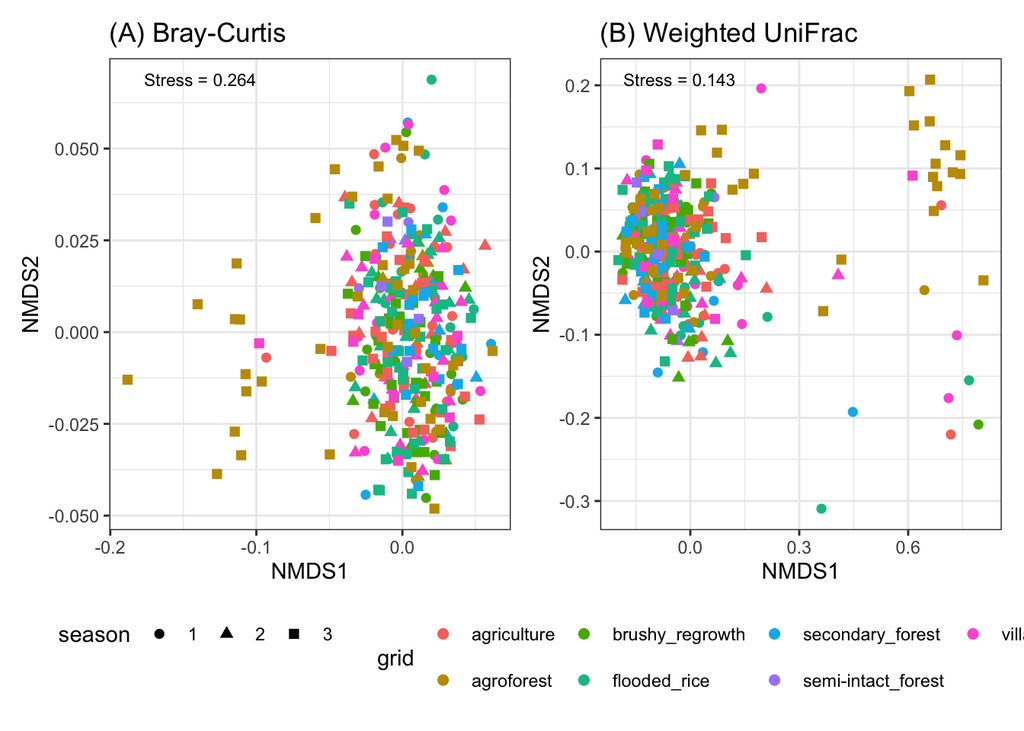

```r
# plotting
g1 + g2 + plot_layout(guides='collect') &
  theme(legend.position='bottom')
```

```r
cat('\n','\n')
```

# 3 Microbial Groups

## 3.1 Genus

```r
# taking only ASVs with known Genus
data_tax <- data_asv_tax %>%
  distinct(host_ID, asv_core, Genus) %>%
  filter(!is.na(Genus))

# known ASVs
asv_genus <- data_asv_tax %>%
  distinct(asv_ID, Genus) %>%
  mutate(name = is.na(Genus))
  print(paste("Percentege of known ASVs:", round(table(asv_genus$name)[1]/nrow(asv_genus)*100, 2)))
```

[1] “Percentege of known ASVs: 43.51”

```r
  cat('\n')
```

```r
# how many Genus?
print(paste("Number of genera:", length(unique(data_tax$Genus))))
```

[1] “Number of genera: 120”

```r
cat('\n')
```

```r
# making unique samples (host_ID+asv_core)
data_tax_meta <- data_tax %>%
  arrange(host_ID) %>%
  unite(col="sample", host_ID:asv_core, remove = FALSE)

data_tax_meta2 <- data_tax_meta %>% distinct(sample, asv_core)

data_tax_summary <- data_tax %>%
  count(asv_core, Genus) %>%
  spread(Genus, n, fill = 0)

# transforming to matrix
data_tax_mat <- data_tax_meta %>%
  select(sample, Genus) %>%
  mutate(n=1) %>%
  spread(Genus, n, fill = 0) %>%
  column_to_rownames("sample") %>%
  as.matrix()

# Perform PERMANOVA
permanova_result <- adonis2(data_tax_mat ~ asv_core, data = data_tax_meta2, method = "jaccard", permutations = 999)
print(paste("F =", permanova_result$F[1]))
```

[1] “F = 65.4590557440489”

```r
cat('\n')
```

```r
print(paste("p-value =", permanova_result$`Pr(>F)`[1]))
```

[1] “p-value = 0.001”

```r
cat('\n')
```

```r
# PCA
tax_pca <- prcomp(data_tax_mat)

# explained variance
ex_var <- tax_pca$sdev ^2
prop_ex_var <- ex_var/sum(ex_var)*100

loadings <- as.data.frame(tax_pca$rotation[, 1:2]) %>% rownames_to_column("Genus") %>%
  mutate(PC1_abs = abs(PC1), PC2_abs = abs(PC2))

tax_scores <- as.data.frame(tax_pca$x[,1:2]) %>% rownames_to_column("sample") %>%
  left_join(data_tax_meta2, by="sample")

loading_top <- loadings %>%
  slice_max(n = 5, order_by = PC1_abs) %>%
  bind_rows(loadings %>% slice_max(n = 5, order_by = PC2_abs))

g1 <- tax_scores %>%
  ggplot(aes(PC1, PC2, color=asv_core)) +
  geom_point() +
  geom_segment(data = loading_top, inherit.aes = FALSE, aes(x = 0, y = 0, xend = PC1*6, yend = PC2*6),
                 arrow = arrow(length = unit(0.15, "cm"))) +
  annotate("label", x = (loading_top$PC1*6), y = (loading_top$PC2*6),
     label = loading_top$Genus, size=3, label.size=0.1, label.padding=unit(0.05, "lines")) +
  theme_bw() +
  theme(panel.border = element_rect(colour = "black", size=1))+
  scale_fill_manual(values=group.colors) +
  labs(x = paste("PC1 (",round(prop_ex_var[1],2),"%)", sep = ""), y = paste("PC2 (",round(prop_ex_var[2],2),"%)", sep = ""),
       title = "(A) Genus", color = "ASV Group")
```

## 3.2 Family

```r
# taking only ASVs with known Family
data_tax <- data_asv_tax %>%
  distinct(host_ID, asv_core, Family) %>%
  filter(!is.na(Family))

# known ASVs
asv_genus <- data_asv_tax %>%
  distinct(asv_ID, Family) %>%
  mutate(name = is.na(Family))
  print(paste("Percentege of known ASVs:", round(table(asv_genus$name)[1]/nrow(asv_genus)*100, 2)))
```

[1] “Percentege of known ASVs: 90.1”

```r
  cat('\n')
```

```r
# how many Family?
print(paste("Number of families:", length(unique(data_tax$Family))))
```

[1] “Number of families: 56”

```r
cat('\n')
```

```r
# making unique samples (host_ID+asv_core)
data_tax_meta <- data_tax %>%
  arrange(host_ID) %>%
  unite(col="sample", host_ID:asv_core, remove = FALSE)

data_tax_meta2 <- data_tax_meta %>% distinct(sample, asv_core)

data_tax_summary <- data_tax %>%
  count(asv_core, Family) %>%
  spread(Family, n, fill = 0)

# transforming to matrix
data_tax_mat <- data_tax_meta %>%
  select(sample, Family) %>%
  mutate(n=1) %>%
  spread(Family, n, fill = 0) %>%
  column_to_rownames("sample") %>%
  as.matrix()

# Perform PERMANOVA
permanova_result <- adonis2(data_tax_mat ~ asv_core, data = data_tax_meta2, method = "jaccard", permutations = 999)
print(paste("F =", permanova_result$F[1]))
```

[1] “F = 84.0285281835418”

```r
cat('\n')
```

```r
print(paste("p-value =", permanova_result$`Pr(>F)`[1]))
```

[1] “p-value = 0.001”

```r
cat('\n')
```

```r
# PCA
tax_pca <- prcomp(data_tax_mat)

# explained variance
ex_var <- tax_pca$sdev ^2
prop_ex_var <- ex_var/sum(ex_var)*100

loadings <- as.data.frame(tax_pca$rotation[, 1:2]) %>% rownames_to_column("Family") %>%
  mutate(PC1_abs = abs(PC1), PC2_abs = abs(PC2))

tax_scores <- as.data.frame(tax_pca$x[,1:2]) %>% rownames_to_column("sample") %>%
  left_join(data_tax_meta2, by="sample")

loading_top <- loadings %>%
  slice_max(n = 5, order_by = PC1_abs) %>%
  bind_rows(loadings %>% slice_max(n = 5, order_by = PC2_abs))

g2 <- tax_scores %>%
  ggplot(aes(PC1, PC2, color=asv_core)) +
  geom_point() +
  geom_segment(data = loading_top, inherit.aes = FALSE, aes(x = 0, y = 0, xend = PC1*4, yend = PC2*4),
                 arrow = arrow(length = unit(0.15, "cm"))) +
  annotate("label", x = (loading_top$PC1*4), y = (loading_top$PC2*4),
     label = loading_top$Family, size=3, label.size=0.1, label.padding=unit(0.05, "lines")) +
  scale_x_continuous(limits = c(-2, 2.7)) +
  theme_bw() +
  theme(panel.border = element_rect(colour = "black", size=1))+
  scale_fill_manual(values=group.colors) +
  labs(x = paste("PC1 (",round(prop_ex_var[1],2),"%)", sep = ""), y = paste("PC2 (",round(prop_ex_var[2],2),"%)", sep = ""),
       title = "(B) Family", color = "ASV Group")
```

## 3.3 Figure

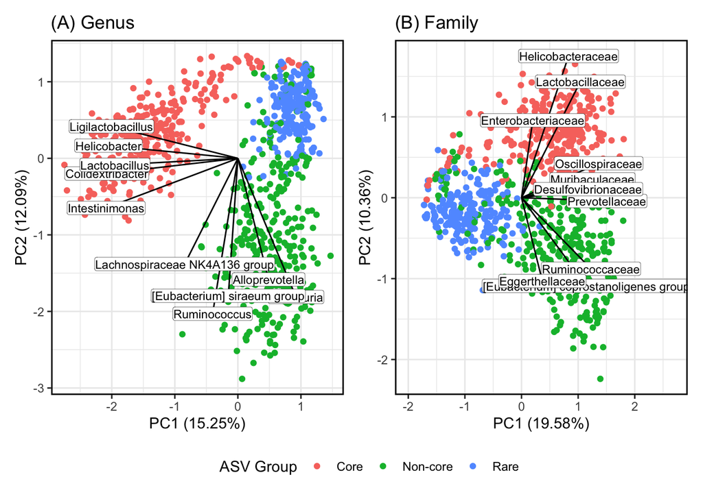

```r
# plotting
g1 + g2 + plot_layout(guides='collect') &
  theme(legend.position='bottom')
```

```r
cat('\n','\n')
```

# 4 Network exploration

```r
# loop for three groups
for (i in 1:3) {

  cat('##',core_names[i],'{.tabset}','\n','\n')

  cat('### ASVs degree distribution','\n')

  print(asv_degree_distribution_three_groups[[i]])
  cat('\n','\n')

  # calculating connectance
  connectance_data <- modules_table_three_groups %>%
    filter(asv_core == core_names[i])

  cat('No. of hosts: ', length(unique(connectance_data$host_ID)) ,'\n','\n')
  cat('No. of ASVs: ', length(unique(connectance_data$asv_ID)) ,'\n','\n')
  cat('Connectance: ', nrow(connectance_data) / (length(unique(connectance_data$host_ID)) * length(unique(connectance_data$asv_ID))) ,'\n','\n')


  cat('### Modules','\n')
  cat('The color indicates number of host individuals in the module / total number of hosts in the whole grid [%]','\n','\n')

  print(modules_three_groups[[i]])
  cat('\n','\n')

  cat('### Modules size','\n')
  print(modules_size_three_groups[[i]])
  cat('\n','\n')

  cat('### No. of land uses','\n')
  print(modules_grid_three_groups[[i]])
  cat('\n','\n')

}
```

## 4.1 Core

### 4.1.1 ASVs degree distribution

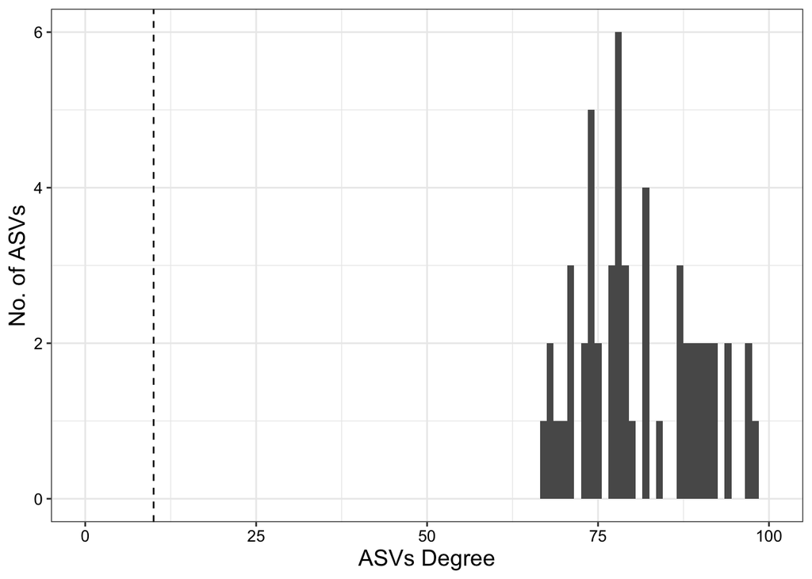

No. of hosts: 334

No. of ASVs: 102

Connectance: 0.3419338

### 4.1.2 Modules

The color indicates number of host individuals in the module / total number of hosts in the whole grid [%]

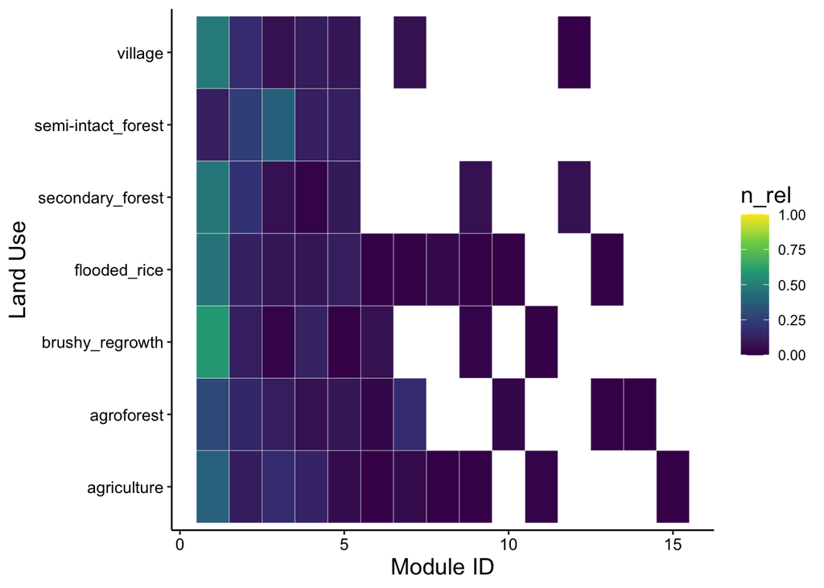

### 4.1.3 Modules size

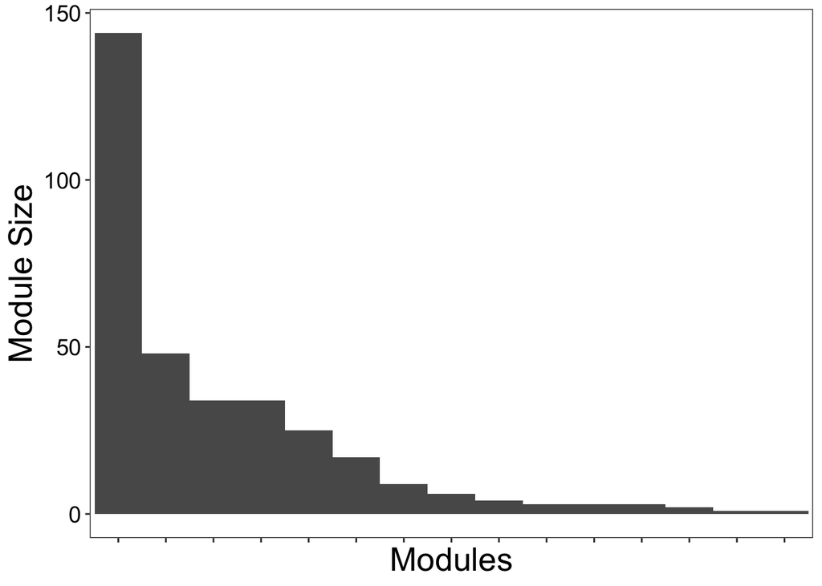

### 4.1.4 No. of land uses

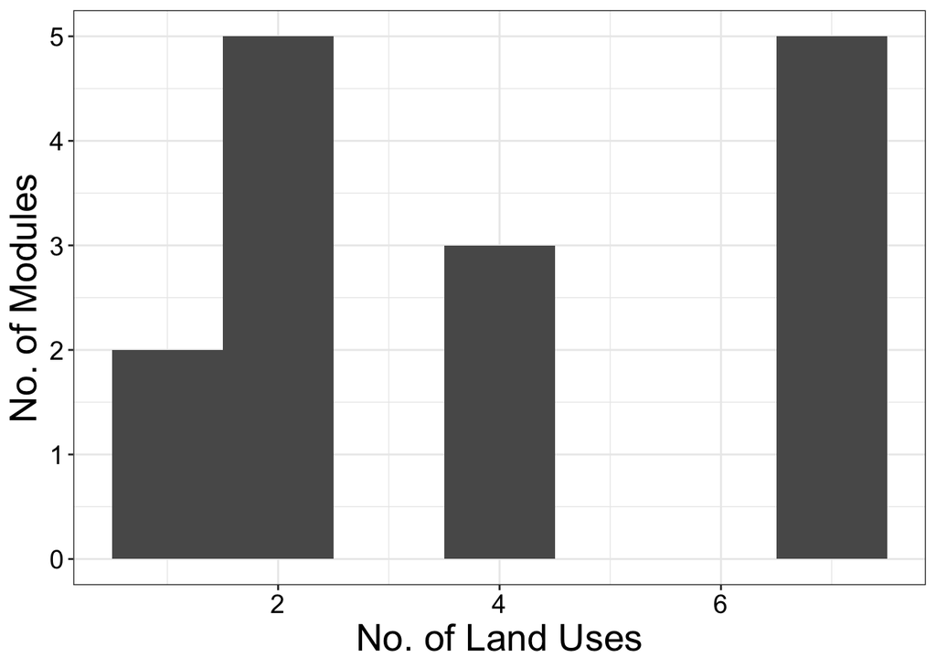

## 4.2 Non-core

### 4.2.1 ASVs degree distribution

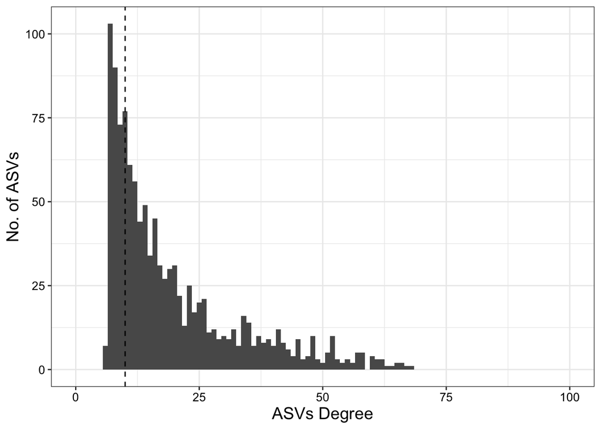

No. of hosts: 336

No. of ASVs: 1131

Connectance: 0.05827913

### 4.2.2 Modules

The color indicates number of host individuals in the module / total number of hosts in the whole grid [%]

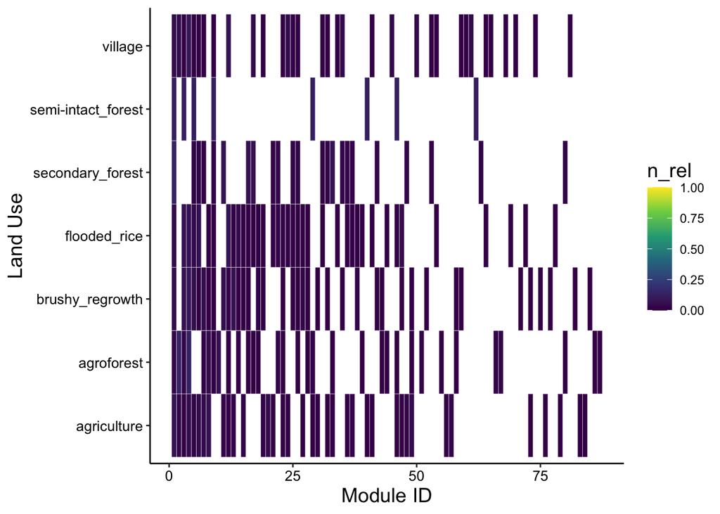

### 4.2.3 Modules size

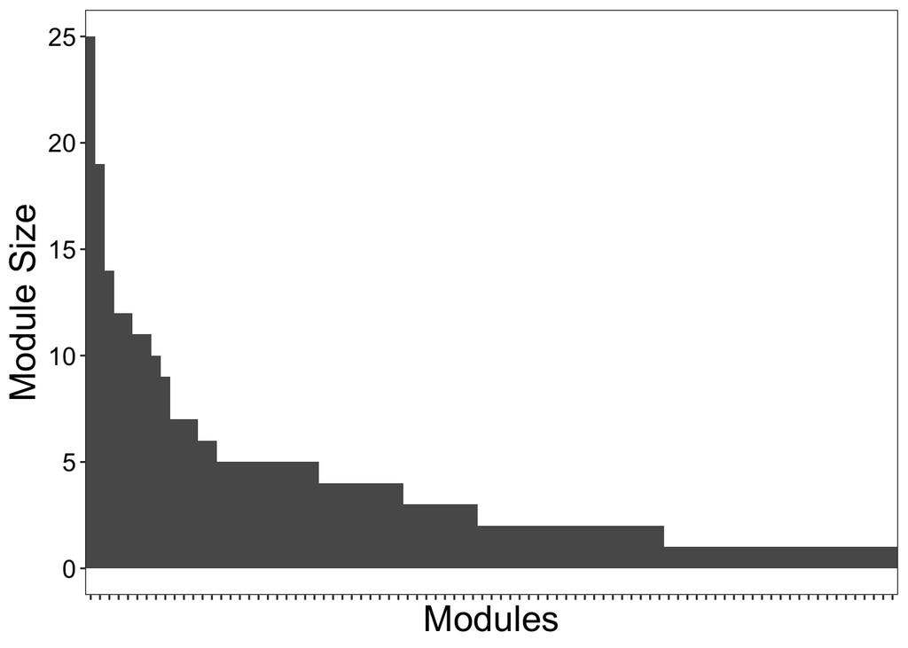

### 4.2.4 No. of land uses

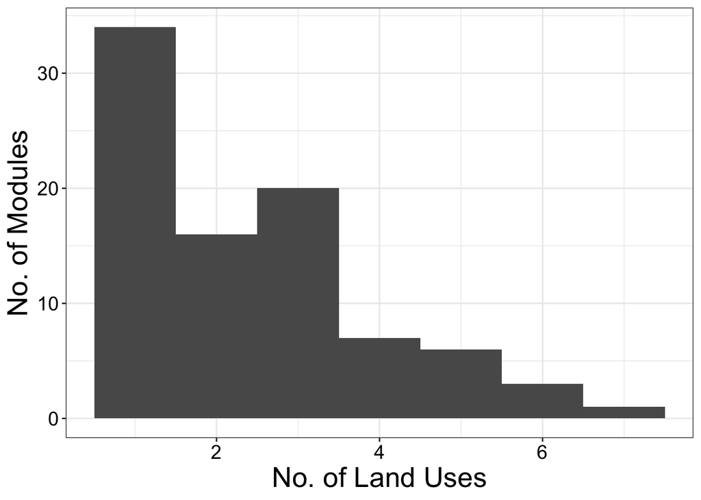

## 4.3 Rare

### 4.3.1 ASVs degree distribution

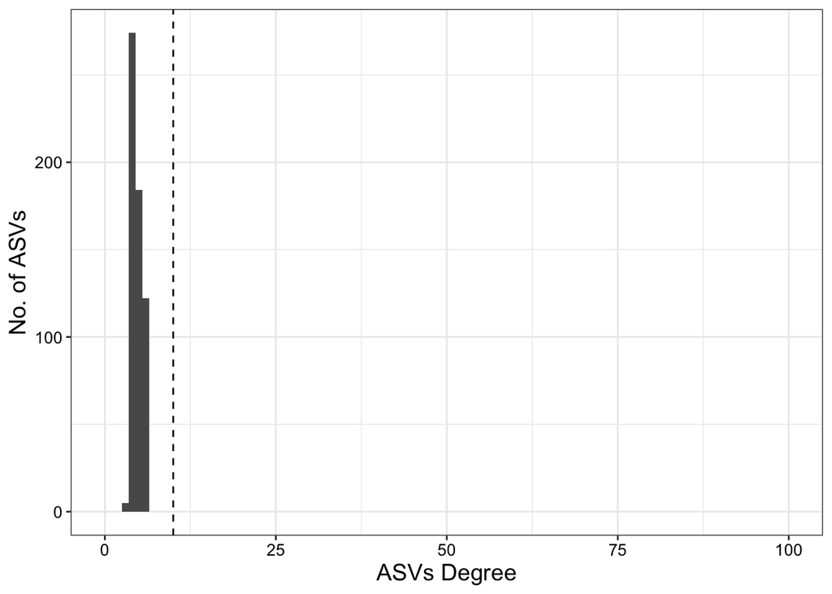

No. of hosts: 325

No. of ASVs: 585

Connectance: 0.01453254

### 4.3.2 Modules

The color indicates number of host individuals in the module / total number of hosts in the whole grid [%]

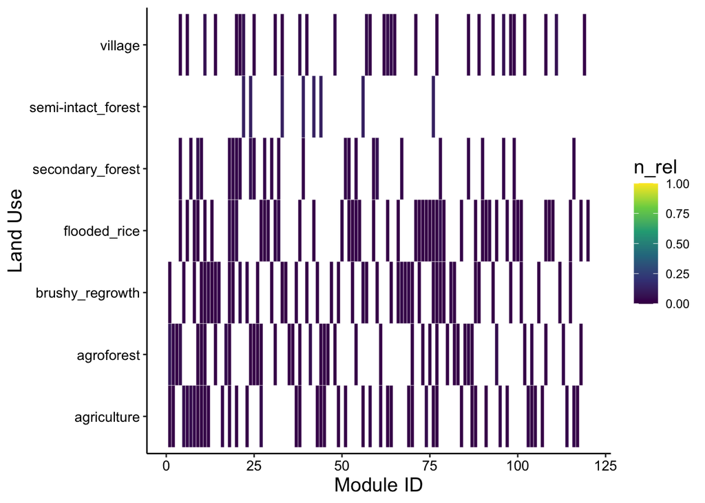

### 4.3.3 Modules size

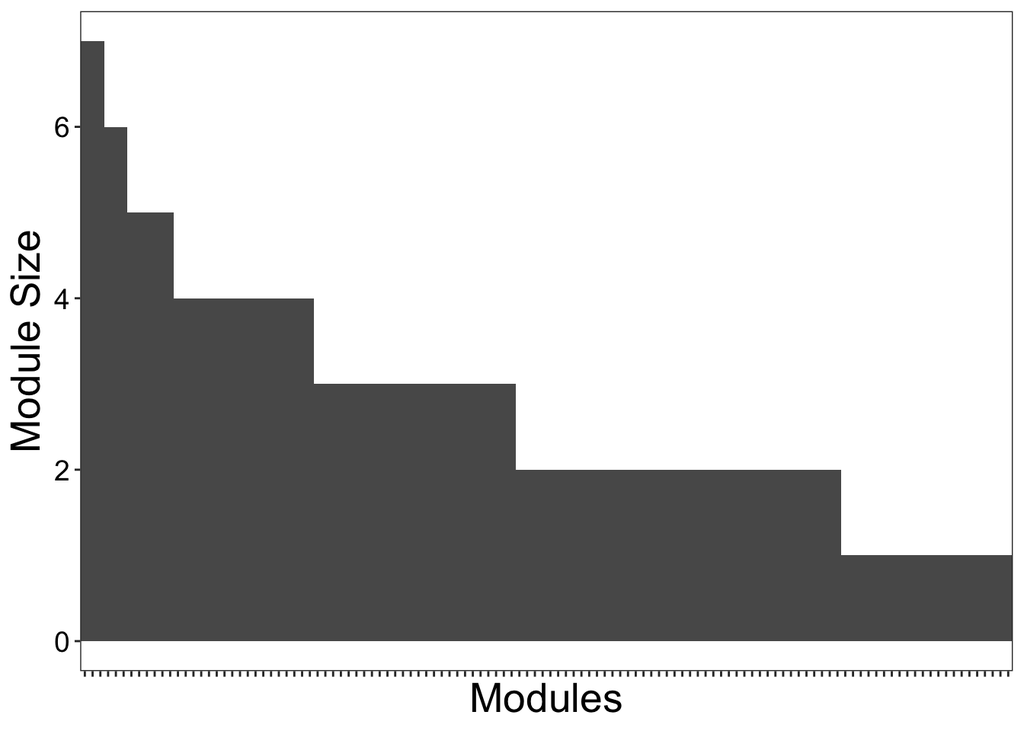

### 4.3.4 No. of land uses

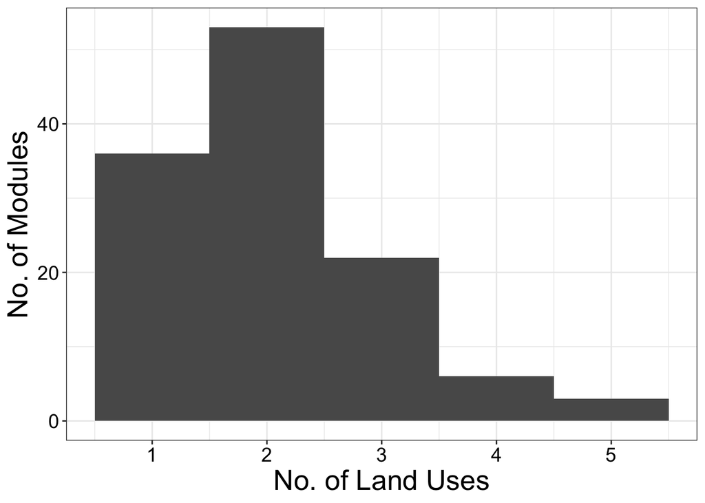

# 5 Modular Structure Exploration

## 5.1 Modules size

```r
library(ggsignif)
#library(ggbreak)

modules_sizes <- modules_table_three_groups %>%
  group_by(asv_core, host_group) %>%
  summarise(n = n_distinct(host_ID))

# summary
cat('Summary','\n')
```

Summary

```r
modules_size_summary <- modules_sizes %>%
  group_by(asv_core) %>%
  summarise(mean = mean(n), sd = sd(n))
print(knitr::kable(modules_size_summary))
```

| asv_core | mean | sd |
| --- | --- | --- |
| Core | 22.266667 | 36.834508 |
| Non-core | 3.862069 | 4.049612 |
| Rare | 2.708333 | 1.410619 |

```r
cat('\n')
```

```r
# ANOVA between groups
cat('ANOVA','\n')
```

ANOVA

```r
anova_result <- aov(n ~ asv_core, data = modules_sizes)
print(paste("F =", summary(anova_result)[[1]][["F value"]][1]))
```

[1] “F = 27.3476311582381”

```r
cat('\n')
```

```r
print(paste("p-value =", summary(anova_result)[[1]][["Pr(>F)"]][1]))
```

[1] “p-value = 2.49955925103282e-11”

```r
cat('\n')
```

```r
# Perform Tukey's HSD post hoc test
cat('Tukey post-hoc','\n')
```

Tukey post-hoc

```r
tukey_result <- TukeyHSD(anova_result)
# Extract the test statistics (q values) from the Tukey HSD results
tukey_q <- tukey_result$asv_core[, "diff"] / tukey_result$asv_core[, "lwr"]
tukey_result <- cbind(tukey_result$asv_core, q_value = tukey_q) %>%
  as.data.frame() %>%
  rownames_to_column("comp")
print(knitr::kable(tukey_result))
```

| comp | diff | lwr | upr | p adj | q_value |
| --- | --- | --- | --- | --- | --- |
| Non-core-Core | -18.404598 | -24.809570 | -11.999625 | 0.0000000 | 0.7418346 |
| Rare-Core | -19.558333 | -25.832457 | -13.284210 | 0.0000000 | 0.7571225 |
| Rare-Non-core | -1.153736 | -4.379684 | 2.072212 | 0.6761125 | 0.2634290 |

```r
cat('\n')
```

```r
  g1 <- modules_sizes %>%
  ggplot(aes(x=asv_core, y=n, fill=asv_core)) +
  geom_boxplot(outliers = FALSE, alpha = 0.9) +
  geom_jitter(color="black", size=1) +
  theme_classic() +
  #scale_y_continuous(limits = c(0, 145)) +
  #scale_y_break(c(50,130), space=0.4, ticklabels = c(130,140))+
  geom_signif(comparisons = list(c("Core", "Non-core"),c("Core", "Rare"),c("Non-core", "Rare")),
              annotations = c("***","***","ns"),  y_position = c(90,100,80), tip_length = 0) +
  geom_point(data = modules_size_summary, aes(x=asv_core, y = mean), position = position_dodge(width = 0.75), size = 2, color="#d62828",alpha=0.8, show.legend=F) +
  theme(axis.text = element_text(size = 11, color = 'black'), title = element_text(size = 15), legend.position = "none") +
  scale_fill_manual(values=group.colors) +
  labs(x="ASV Group", y="Module Size", title = "(A)")
```

## 5.2 Modules No. of Grids

```r
modules_grids <- modules_table_three_groups %>%
  group_by(asv_core, host_group) %>%
  summarise(n = n_distinct(grid))

# summary
cat('Summary','\n')
```

Summary

```r
modules_grids_summary <- modules_grids %>%
  group_by(asv_core) %>%
  summarise(mean = mean(n), sd = sd(n))
print(knitr::kable(modules_grids_summary))
```

| asv_core | mean | sd |
| --- | --- | --- |
| Core | 3.933333 | 2.433888 |
| Non-core | 2.402299 | 1.505492 |
| Rare | 2.058333 | 0.955267 |

```r
cat('\n')
```

```r
# ANOVA between groups
cat('ANOVA','\n')
```

ANOVA

```r
anova_result <- aov(n ~ asv_core, data = modules_grids)
print(paste("F =", summary(anova_result)[[1]][["F value"]][1]))
```

[1] “F = 13.5579186926062”

```r
cat('\n')
```

```r
print(paste("p-value =", summary(anova_result)[[1]][["Pr(>F)"]][1]))
```

[1] “p-value = 2.81092092602323e-06”

```r
cat('\n')
```

```r
# Perform Tukey's HSD post hoc test
cat('Tukey post-hoc','\n')
```

Tukey post-hoc

```r
tukey_result <- TukeyHSD(anova_result)
# Extract the test statistics (q values) from the Tukey HSD results
tukey_q <- tukey_result$asv_core[, "diff"] / tukey_result$asv_core[, "lwr"]
tukey_result <- cbind(tukey_result$asv_core, q_value = tukey_q) %>%
  as.data.frame() %>%
  rownames_to_column("comp")
print(knitr::kable(tukey_result))
```

| comp | diff | lwr | upr | p adj | q_value |
| --- | --- | --- | --- | --- | --- |
| Non-core-Core | -1.5310345 | -2.4073979 | -0.6546711 | 0.0001568 | 0.6359707 |
| Rare-Core | -1.8750000 | -2.7334600 | -1.0165400 | 0.0000017 | 0.6859438 |
| Rare-Non-core | -0.3439655 | -0.7853574 | 0.0974264 | 0.1594197 | 0.4379732 |

```r
cat('\n')
```

```r
  g2 <- modules_grids %>%
  ggplot(aes(x=asv_core, y=n, fill=asv_core)) +
  geom_boxplot(outliers = FALSE, alpha = 0.9) +
  geom_jitter(color="black", size=1) +
  theme_classic() +
  scale_y_continuous(limits = c(0, 9), breaks = seq(0,8,by=2)) +
  geom_signif(comparisons = list(c("Core", "Non-core"),c("Core", "Rare"),c("Non-core", "Rare")),
              annotations = c("***","***","ns"),  y_position = c(7.7,8.5,7), tip_length = 0) +
  geom_point(data = modules_grids_summary, aes(x=asv_core, y = mean), position = position_dodge(width = 0.75), size = 2, color="#d62828",alpha=0.8, show.legend=F) +
  theme(axis.text = element_text(size = 11, color = 'black'), title = element_text(size = 15), legend.position = "none") +
  scale_fill_manual(values=group.colors) +
  labs(x="ASV Group", y="No. of Land Uses", title = "(B)")
```

## 5.3 No. of Modules

```r
modules_per_grid <- modules_table_three_groups %>%
  group_by(asv_core, grid) %>%
  summarise(n = n_distinct(host_group))

# summary
cat('Summary','\n')
```

Summary

```r
modules_per_grid_summary <- modules_per_grid %>%
  group_by(asv_core) %>%
  summarise(mean = mean(n), sd = sd(n))
print(knitr::kable(modules_per_grid_summary))
```

| asv_core | mean | sd |
| --- | --- | --- |
| Core | 8.428571 | 2.299068 |
| Non-core | 29.857143 | 10.976165 |
| Rare | 35.285714 | 14.727687 |

```r
cat('\n')
```

```r
# ANOVA between groups
cat('ANOVA','\n')
```

ANOVA

```r
anova_result <- aov(n ~ asv_core, data = modules_per_grid)
print(paste("F =", summary(anova_result)[[1]][["F value"]][1]))
```

[1] “F = 12.3585325180656”

```r
cat('\n')
```

```r
print(paste("p-value =", summary(anova_result)[[1]][["Pr(>F)"]][1]))
```

[1] “p-value = 0.000418832035424275”

```r
cat('\n')
```

```r
# Perform Tukey's HSD post hoc test
cat('Tukey post-hoc','\n')
```

Tukey post-hoc

```r
tukey_result <- TukeyHSD(anova_result)
# Extract the test statistics (q values) from the Tukey HSD results
tukey_q <- tukey_result$asv_core[, "diff"] / tukey_result$asv_core[, "lwr"]
tukey_result <- cbind(tukey_result$asv_core, q_value = tukey_q) %>%
  as.data.frame() %>%
  rownames_to_column("comp")
print(knitr::kable(tukey_result))
```

| comp | diff | lwr | upr | p adj | q_value |
| --- | --- | --- | --- | --- | --- |
| Non-core-Core | 21.428571 | 6.848834 | 36.00831 | 0.0039719 | 3.1287914 |
| Rare-Core | 26.857143 | 12.277405 | 41.43688 | 0.0004976 | 2.1875260 |
| Rare-Non-core | 5.428571 | -9.151166 | 20.00831 | 0.6165394 | -0.5932109 |

```r
cat('\n')
```

```r
  g3 <- modules_per_grid %>%
  ggplot(aes(x=asv_core, y=n, fill=asv_core)) +
  geom_boxplot(outliers = FALSE, alpha = 0.9) +
  geom_jitter(color="black", size=1) +
  theme_classic() +
  scale_y_continuous(limits = c(0, 60)) +
  geom_signif(comparisons = list(c("Core", "Non-core"),c("Core", "Rare"),c("Non-core", "Rare")),
              annotations = c("***","***","ns"),  y_position = c(45,55,50), tip_length = 0) +
  geom_point(data = modules_per_grid_summary, aes(x=asv_core, y = mean), position = position_dodge(width = 0.75), size = 2, color="#d62828",alpha=0.8, show.legend=F) +
  theme(axis.text = element_text(size = 11, color = 'black'), title = element_text(size = 15), legend.position = "none") +
  scale_fill_manual(values=group.colors) +
  labs(x="ASV Group", y="No. of Modules per Land Use", title = "(C)")
```

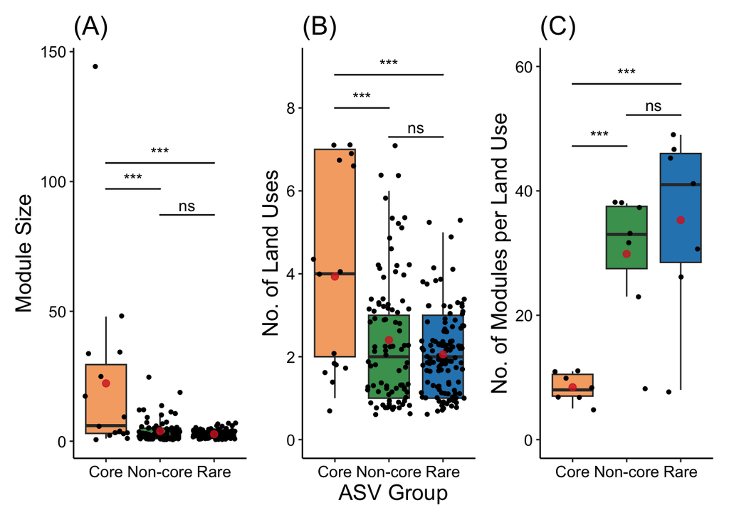

```r
# plotting
g1+g2+g3 + plot_layout(axis_titles = "collect_x")
```

# 6 Phylogenetic analysis

```r
# beta-NTI same module?
betaNTI_final <- betaNTI_three_groups %>%
  mutate(same_module = ifelse(host_group1==host_group2, "Same","Different"))

# Raup-Crick same module?
raupc_final <- raupc_three_groups %>%
  mutate(same_module = ifelse(host_group1==host_group2, "Same","Different"))
```

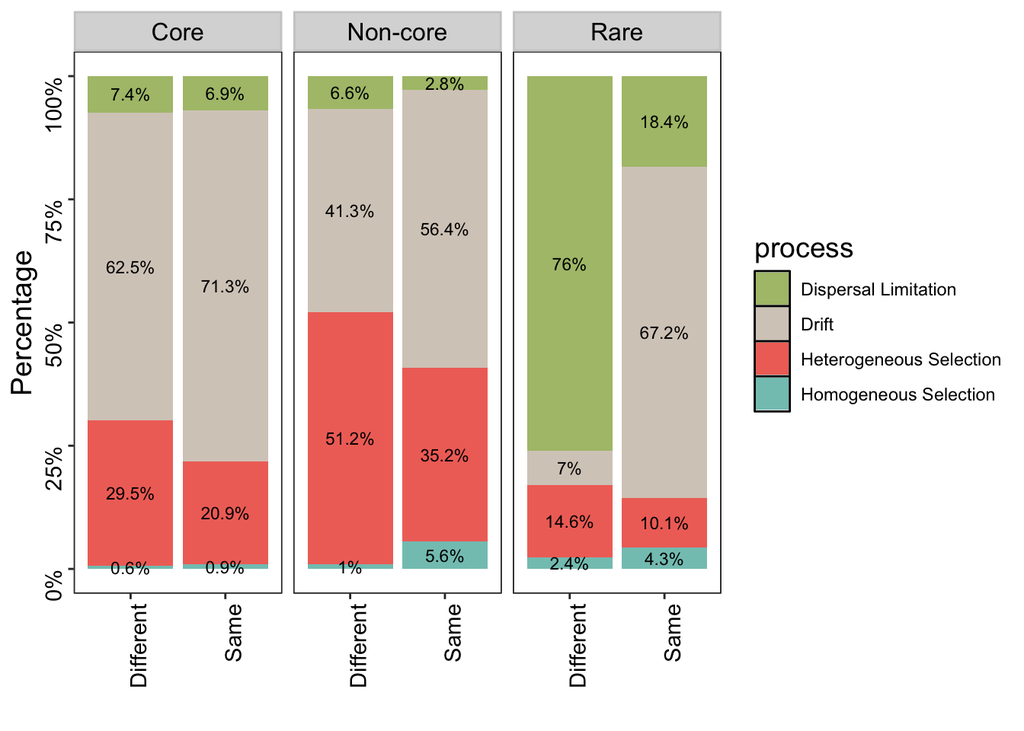

```r
# combining final results
assembly_final <- betaNTI_final %>%
  full_join(raupc_final %>% dplyr::select(host1,host2,raupc,asv_core), by=c("host1","host2","asv_core"))

#a=assembly_final %>% filter(is.na(betaNTI))

# calculating the process
assembly_final %<>% mutate(process = case_when(betaNTI>2 ~ "Heterogeneous Selection",
                                               betaNTI<(-2) ~ "Homogeneous Selection",
                                               (betaNTI<=2 & betaNTI>=(-2) & raupc>0.95) ~ "Dispersal Limitation",
                                               (betaNTI<=2 & betaNTI>=(-2) & raupc<(-0.95)) ~ "Homogenizing Dispersal",
                                               .default = "Drift"))

# summary
assembly_summary <- assembly_final %>%
  count(asv_core, same_module, process)

assembly_summary_total <- assembly_summary %>%
  group_by(asv_core, same_module) %>%
  summarise(n_total = sum(n))

#plotting
g <- assembly_summary %>%
  left_join(assembly_summary_total, by=c("asv_core","same_module")) %>%
  mutate(n_p = n/n_total) %>%
  ggplot(aes(fill=process, x=same_module, y=n_p)) +
  geom_bar(position="fill", stat="identity") +
  facet_wrap(~asv_core) +
  scale_y_continuous(labels = scales::percent) +
  geom_text(aes(label = paste0(round(n_p*100,1),"%")),
            position = position_stack(vjust = 0.5), size = 3)+
  theme_bw() +
  theme(axis.text = element_text(size = 11, color = 'black', angle = 90, vjust = 0.5, hjust=1), title = element_text(size = 14),
        strip.text = element_text(size=12, color = 'black'), strip.background = element_rect(color = "grey80", size = 1),
        panel.grid = element_blank(), panel.background = element_rect(colour = "black")) +
  scale_fill_manual(values=c("#adc178","#d6ccc2","#f07167","#83c5be")) +
  labs(x="", y="Percentage")
print(g)
```

# 7 Normalized Mutual Information (NMI)

```r
cat('## Observed NMI','\n')
```

## 7.1 Observed NMI

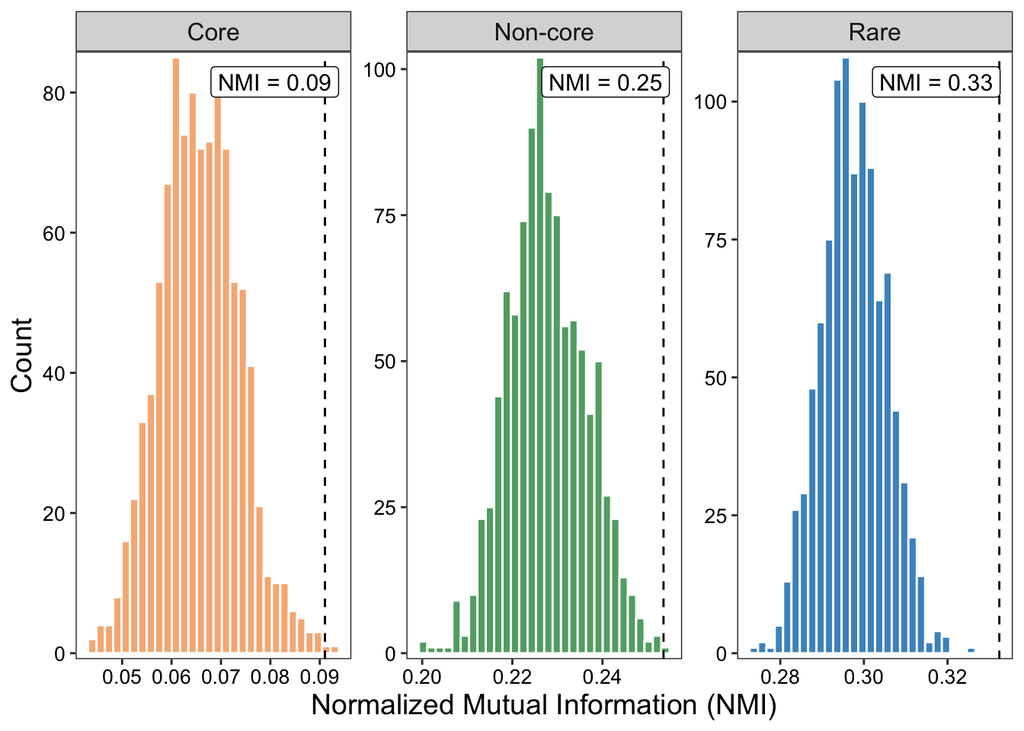

```r
# making a data frame out of the shuffled results
# loop for three villages
nmi_observed_df_tv <- NULL
for (j in 1:3) {
  nmi_observed_df <- data_frame(nmi = nmi_observed_three_groups[[j*2]]) %>%
    mutate(asv_core = core_names[j])
  nmi_observed_df_tv <- rbind(nmi_observed_df_tv, nmi_observed_df)
}

# making a data frame out of the observed results
nmi_observed_three_groups_df <- nmi_observed_three_groups[[1]] %>%
  bind_rows(nmi_observed_three_groups[[3]]) %>%
  bind_rows(nmi_observed_three_groups[[5]]) %>%
  mutate(asv_core = core_names)

g <- nmi_observed_df_tv %>%
  ggplot(aes(nmi, fill=asv_core)) +
  geom_histogram(alpha=0.8, color="white") +
  facet_wrap(~asv_core, scales="free") +
  scale_y_continuous(limits = c(0, 100)) +
  geom_vline(data=nmi_observed_three_groups_df, aes(xintercept = nmi), linetype='dashed', color="black") +
  geom_label(data = nmi_observed_three_groups_df, aes(label = paste("NMI =", round(nmi,2)), x = Inf, y = Inf),
             vjust = 1.5,hjust = 1.1, size = 4, color = "black", fill="white") +
  theme_bw() +

  theme(axis.text = element_text(size = 10, color = 'black'), title = element_text(size = 14), strip.text = element_text(size=12), panel.grid = element_blank(), legend.position="none") +
  scale_y_continuous(expand = expansion(mult = c(0.01, 0.01))) +
  scale_fill_manual(values=group.colors) +
  labs(x="Normalized Mutual Information (NMI)", y="Count")
print(g)
```

```r
cat('\n','\n')
```

# 8 Modules similarity across land use change gradient

## 8.1 Correlations between variables

Distance is a proxy for habitat degradation.

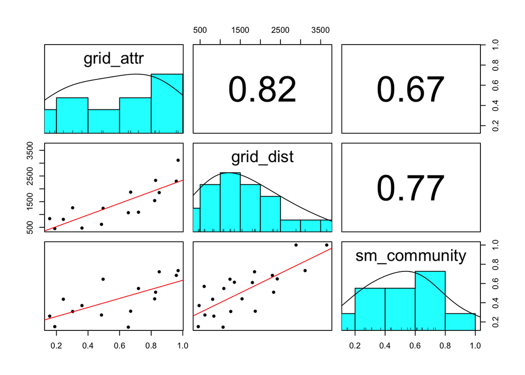

```r
# reading grid similarity results
grids_similarity_attr <- read_csv("../data/data_processed/village_summary.csv")

# correlations between variables
# loop for three villages
library(psych)
print(psych::pairs.panels(grids_similarity_attr %>% filter(village == vil) %>%  select(-village,-grid1,-grid2), ellipses = F, lm = T))
```

NULL

```r
cat('\n','\n')
```

## 8.2 Mantel test

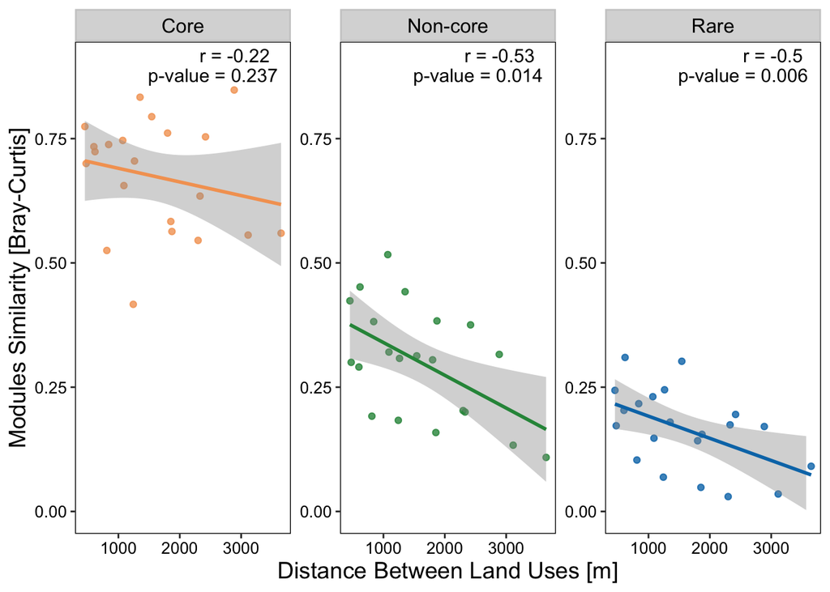

```r
# mantel test for: modules similarity ~ distance between grids

# distance between grids matrices
load("../data/data_processed/distance_three_villages.RData")
names(grid_distance_three_villages) <- c("Mandena", "Sarahandrano", "Andatsakala")
grid_distance <- grid_distance_three_villages[[vil]]

mantel_result_three_groups <- NULL
final_data_three_groups <- NULL

# loop for three asv groups
for (i in 1:3) {

  modules_similarity <- modules_similarity_three_groups[[i]]
  grid_names <- rownames(modules_similarity)
  # filtering the distance matrix to the existing grids
  grid_distance <- grid_distance[grid_names, grid_names]

  # calculating mantel test
  mantel_result <- vegan::mantel(modules_similarity, grid_distance)
  mantel_result_df <- data_frame(r = round(mantel_result$statistic,2),
                                 pvalue = round(1-mantel_result$signif,4),
                                 asv_core = core_names[i])
  mantel_result_three_groups <- rbind(mantel_result_three_groups, mantel_result_df)


  # transforming to long format
  modules_similarity_m <- modules_similarity
  modules_similarity_m[lower.tri(modules_similarity_m)] <- NA
  diag(modules_similarity_m) <- NA
  final_data <- melt(modules_similarity_m) %>%
    filter(!is.na(value)) %>%
    mutate(asv_core = core_names[i]) %>%
    dplyr::rename(grid1 = Var2, grid2 = Var1, module_similarity = value) %>%
    left_join(grids_similarity_attr %>% filter(village == vil), by=c("grid1","grid2"))

  final_data_three_groups <- rbind(final_data_three_groups, final_data)

}

# plotting
g <- final_data_three_groups %>%
  ggplot(aes(y=module_similarity, x=grid_dist, color = asv_core)) +
  geom_point(alpha = 0.8) +
  facet_wrap(~asv_core, scales="free")+
  scale_y_continuous(limits = c(0.0, 0.9)) +
  geom_smooth(method = "glm", se=T, method.args = list(family = "gaussian")) +
  geom_text(data = mantel_result_three_groups, aes(label = paste("r =", r), x = Inf, y = Inf),
            hjust = 1.3, vjust = 1.5, size = 4, color = "black") +
  geom_text(data = mantel_result_three_groups, aes(label = paste("p-value =", pvalue), x = Inf, y = Inf),
            hjust = 1.1, vjust = 3, size = 4, color = "black") +
  theme_bw() +
  theme(axis.text = element_text(size = 10, color = 'black'), title = element_text(size = 14),
        strip.text = element_text(size=12, color = 'black'), strip.background = element_rect(color = "grey80", size = 1),
        panel.grid = element_blank(), legend.position = "none", panel.border = element_rect(color = "black")) +
  scale_color_manual(values=group.colors) +
  labs(x = "Distance Between Land Uses [m]", y = "Modules Similarity [Bray-Curtis]")
print(g)
```

```r
cat('\n','\n')
```

# 9 Link prediction